# Polymorphic inversions underlie the shared genetic susceptibility to prevalent common diseases

Juan R Gonzalez, Carlos Ruiz-Arenas, Alejandro Caceres, Ignasi Moran, Marcos Lopez, Lorena Alonso, Ignacio Tolosana, Marta Guindo-Martinez, Josep M Mercader, Tonu Esko, David Torrents, Josefa Gonzalez, Luis A Perez-Jurado

18 mayo 2020

# 1 Getting started

Let us load the required libraries to reproduce paper’s results:

```r
library(tidyverse)
library(FactoMineR)
library(factoextra)
library(nlme)
library(org.Hs.eg.db)
library(clusterProfiler)
library(scoreInvHap)
library(SNPassoc)
library(snpStats)
library(meta)
library(RColorBrewer)
library(OmicCircos)
library(compareGroups)
```

Then, some functions are created to facilitate data analysis and visualizations. The functions are loaded by:

```r
source("R/aux_functions.R")
```

The inversion calling is perfomed using `scoreInvHap` Bioconductor package using the imputed data obtained after applying our pipeline described here: https://github.com/isglobal-brge/imputeInversion. The inversion regions of each SNP array or GWAS dataset are first imputed to get all the required SNPs that are used to call inversion genotypes.

# 2 Geographical inversion distribution in European regions

We first are interested in finding population structure at European level. To this end, the Population Reference Sample study (POPRES) obtained from dbGAP (accesion number phs000145.v4.p2) is used. We select those samples passing QC and having European origin:

```r
popres <- read.delim("POPRES/ScoreInvHap_POPRES_final_full.txt",
                     as.is =TRUE, na=c("", NA, " "))
popres <- popres[popres$'STATUS_OVERALL'=="Passed QC",]
```

```r
popres.old <- popres
ll <- grep("inv", colnames(popres.old))
popres <- popres.old[,-ll]

load("POPRES/scoreInvHapClassDFPOPRES.Rdata")
popres <- merge(popres, scClassDF, by.x="SUBJID",
           by.y="row.names")

popres.eur <- subset(popres,
                     GROUPING_CONTINENTAL_ORIGIN ==
                       "European")
```

This is the number of samples per region

```r
table(popres.eur$"GROUPING_PCA_LABEL2")
```

```
EuropeanA EuropeanB   EuropeC   EuropeE EuropeESE   EuropeN  EuropeNE  EuropeNW   EuropeS  EuropeSE
      210        17       186        29        10        15        32       447       227        91
 EuropeSW   EuropeW       Mix
      260      1029       514
```

```r
table(popres.eur$"EUROPEAN_LABEL")
```

```
< table of extent 0 >
```

Let’s estimate the inversion frequencies per european region

```r
ii <- grep("inv", names(popres.eur))
freq.EURreg <- getFreqs(popres.eur,
                        index.inv=ii,
                        grouping = "GROUPING_PCA_LABEL2",
                        sep="")
freq.EURreg
```

```
# A tibble: 13 x 22
   pop   inv1_004 inv1_008 inv11_001 inv11_004 inv12_004 inv12_006 inv14_005 inv16_009 inv17_007
   <fct>    <dbl>    <dbl>     <dbl>     <dbl>     <dbl>     <dbl>     <dbl>     <dbl>     <dbl>
 1 Euro~    11.1      20.1     14.9       33.0      6.22      40.2     26.9       35        17.6
 2 Euro~     6.67     26.7      8.82      38.2     10         43.3     26.9       23.1      30
 3 Euro~    14.9      22.9      9.54      36.4      8         36.6     25.9       37.9      21.4
 4 Euro~    18        12       22.2       33.3      7.69      21.2     32         36.5      30.4
 5 Euro~    30        15       11.1       11.1      5         35       25         31.2      31.2
 6 Euro~     6.67     30       13.3       30        3.57      39.3      3.33      35.7      10
 7 Euro~    10.3      15.5     12.1       32.8      4.84      40.3     37.0       45.3      14.1
 8 Euro~     8.92     19.3     14.4       32.5      6.44      37.1     26.7       39.0      15.3
 9 Euro~    14.4      19.1     14.6       30.5     10.9       33.3     26.4       29.1      22.1
10 Euro~     9.49     24.1     13.9       24.7      8.93      31.0     32.5       30.9      14.7
11 Euro~     9.96     19.1     15.8       32.4      6.91      37.0     27.1       32.5      22.2
12 Euro~    10.6      21.2     15.0       33.7      6.39      36.6     26.5       30.6      21.4
13 Mix       9.06     21.7     13.9       31.3      7.89      36.5     26.9       32.0      19.4
# ... with 12 more variables: inv2_002 <dbl>, inv2_013 <dbl>, inv21_005 <dbl>, inv3_003 <dbl>,
#   inv6_002 <dbl>, inv6_006 <dbl>, inv7_003 <dbl>, inv7_005 <dbl>, inv7_011 <dbl>, inv7_014 <dbl>,
#   inv8_001 <dbl>, invX_006 <dbl>
```

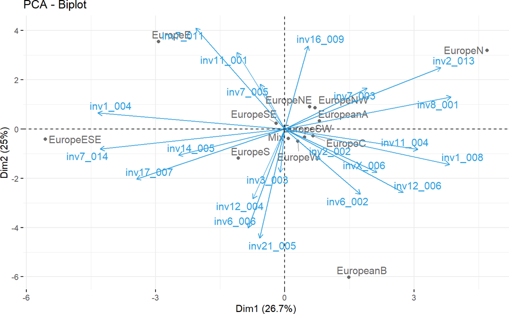

```r
xx <- data.frame(freq.EURreg[,-1])
rownames(xx) <- freq.EURreg$pop
pca.EURreg <- prcomp(xx,
                    center = TRUE, scale = TRUE)
p.1000G.pca <- fviz_pca_biplot(pca.EURreg,
                               repel = TRUE,
                col.var = "#2E9FDF", # Variables color
                col.ind = "#696969"  # Individuals color
                )
p.1000G.pca
```

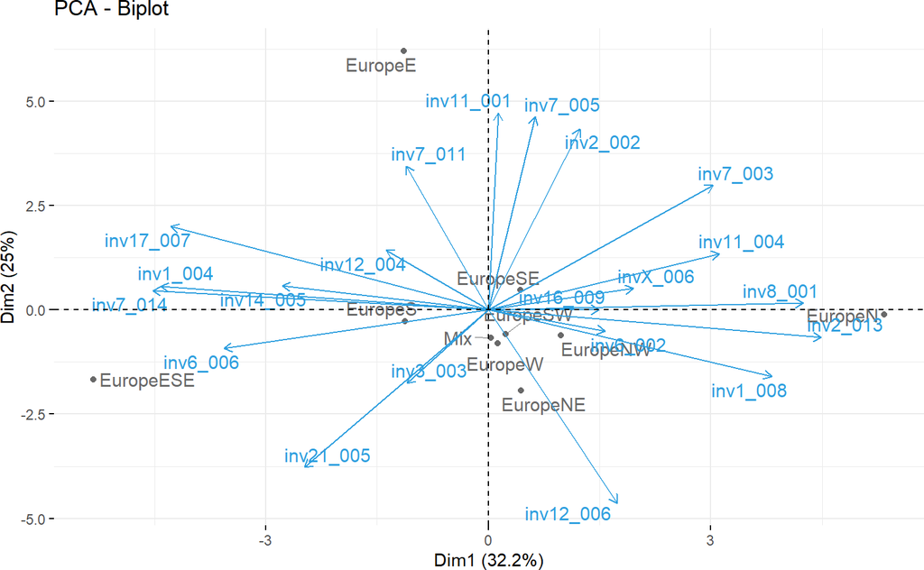

```r
xx2 <- xx[-c(1:3), ]
pca.EURreg2 <- prcomp(xx2, center = TRUE,
                      scale = TRUE)

fviz_pca_biplot(pca.EURreg2, repel = TRUE,
                col.var = "#2E9FDF", # Variables color
                col.ind = "#696969"  # Individuals color
                )
```

Let us estimate the frequencies North-Center-South

```r
popres.eur3 <- popres.eur[popres.eur$GROUPING_PCA_LABEL2%in%
                            c("EuropeN", "EuropeNE", "EuropeNW",
                              "Mix",
                              "EuropeS"),]
popres.eur3$pop <- as.factor(popres.eur3$GROUPING_PCA_LABEL2)
levels(popres.eur3$pop) <- c("North", "North",  "North", "South", "Center")

n.europe <- table(popres.eur3$pop)


ii <- grep("inv", names(popres.eur3))
freq.EURreg2 <- getFreqs(popres.eur3,
                        index.inv=ii,
                        grouping = "pop",
                        sep="")
freq.EURreg2$pop <- relevel(freq.EURreg2$pop,2)
freq.EURreg2 <- data.frame(freq.EURreg2)
rownames(freq.EURreg2) <- freq.EURreg2$pop
freq.EURreg2
```

```
          pop  inv1_004 inv1_008 inv11_001 inv11_004 inv12_004 inv12_006 inv14_005 inv16_009
North   North  8.940397 19.42605  14.25486  32.39741  6.250000  37.39407  26.51869  39.33649
South   South 14.354067 19.13876  14.55399  30.51643 10.869565  33.33333  26.39594  29.14692
Center Center  9.062500 21.66667  13.87755  31.32653  7.894737  36.53846  26.92308  31.98758
       inv17_007 inv2_002 inv2_013 inv21_005 inv3_003 inv6_002 inv6_006 inv7_003 inv7_005 inv7_011
North   15.05618 13.80846 76.61470  51.61290 53.41410 61.28319 7.300885 22.59101 52.14133 61.02784
South   22.13930 11.66667 66.42857  57.37327 61.08491 72.79412 8.088235 26.49770 54.37788 62.44240
Center  19.37901 13.52459 71.92623  52.11694 55.21472 65.03132 8.663883 23.28629 51.20968 61.79435
       inv7_014 inv8_001  invX_006
North  20.12848 56.46651 12.418301
South  24.65438 53.57143  8.461538
Center 23.99194 54.92813 12.138728
```

## 2.1 European countries

We select those countries having more than 20 samples to get robust inversion frequencies estimation and remove those countries that are not in Europe.

```r
tt <- table(popres.eur$COUNTRY_SELF)
sel <- intersect(names(tt)[tt>20],
                 names(tt)[!names(tt)%in%
                             c("Australia", "Canada",
                               "USA", "CEU")])
popres.eur2 <- subset(popres.eur, popres.eur$COUNTRY_SELF%in%sel &
                        !is.na(popres.eur$COUNTRY_SELF))
```

```r
ii <- grep("inv", colnames(popres.eur2))
freq.EURcountry <- getFreqs(popres.eur2,
                            index.inv = ii,
                            grouping = "COUNTRY_SELF",
                            sep="")
freq.EURcountry
```

```
# A tibble: 12 x 22
   pop   inv1_004 inv1_008 inv11_001 inv11_004 inv12_004 inv12_006 inv14_005 inv16_009 inv17_007
   <fct>    <dbl>    <dbl>     <dbl>     <dbl>     <dbl>     <dbl>     <dbl>     <dbl>     <dbl>
 1 Belg~    10.7      31.0     17.4       27.9      6.10      34.1      20.5      32.9      21.8
 2 Engl~    14.5      16.1     16.1       27.4      9.68      35.5      18.3      33.9      19.4
 3 Fran~     7.37     22.4     16.2       33.6      7.61      36.5      27.8      31.3      22.1
 4 Germ~    10.7      23.2      6.10      34.1      6.88      41.9      22.8      39.3      14.9
 5 Irel~     9.09     23.6      8.62      31.0      6.90      32.8      26        31.1      18.4
 6 Italy    14.7      17.6     12.8       31.5     10.2       34.8      26        28.0      22.4
 7 Pola~     8.33     20.8     14.6       29.2      4.35      37.0      31.0      54.2      16
 8 Port~    11.6      18.1     17.1       30.3      7.08      36.7      28.1      37.1      18.3
 9 Spain     9.43     23.0     17.6       32.8      7.6       34.8      26.1      28.0      24.6
10 Swit~    10.9      21.3     14.2       33.3      6.78      36.1      26        30.7      21.1
11 Unit~     8.16     18.6     15.1       33.4      6.36      38.0      27.2      40.3      14.9
12 Yugo~    10.5      25       16.2       25        6.25      35        32.4      32.9      10.3
# ... with 12 more variables: inv2_002 <dbl>, inv2_013 <dbl>, inv21_005 <dbl>, inv3_003 <dbl>,
#   inv6_002 <dbl>, inv6_006 <dbl>, inv7_003 <dbl>, inv7_005 <dbl>, inv7_011 <dbl>, inv7_014 <dbl>,
#   inv8_001 <dbl>, invX_006 <dbl>
```

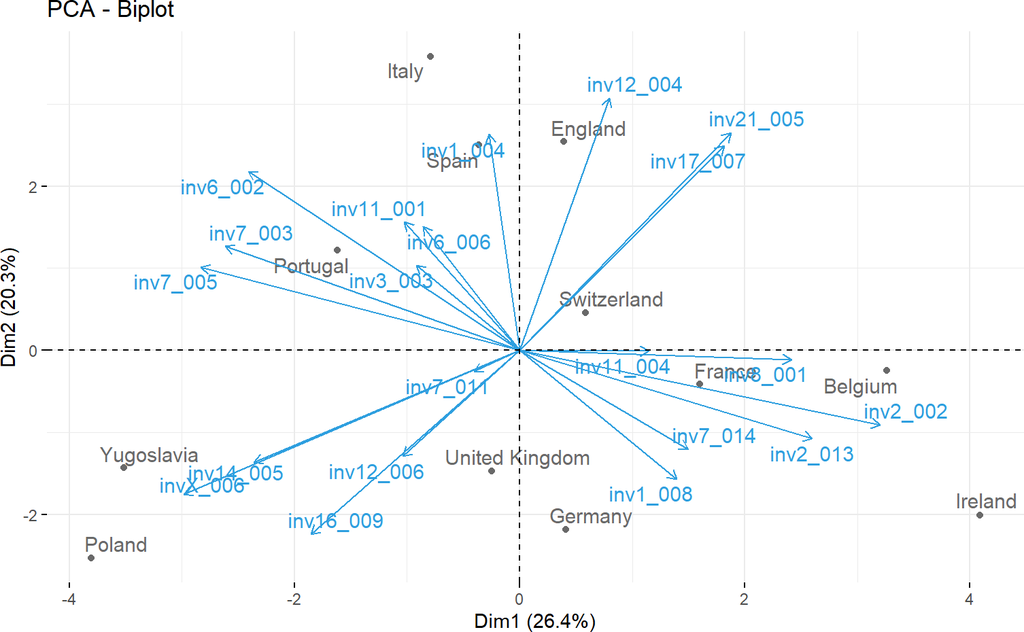

```r
xx <- data.frame(freq.EURcountry[,-1])
rownames(xx) <- freq.EURcountry$pop
pca.EURcountry <- prcomp(xx,
                    center = TRUE, scale = TRUE)
fviz_pca_biplot(pca.EURcountry, repel = TRUE,
                col.var = "#2E9FDF", # Variables color
                col.ind = "#696969"  # Individuals color
                )
```

The major allele frequencies in Europe are

```r
ii <- grep("^inv", names(popres.eur))
x.s <- setupSNP(popres.eur, ii, sep="")
summary(x.s)
```

```
          alleles major.allele.freq HWE      missing (%)
inv1_004  N/I     89.3              0.551687  8.5
inv1_008  N/I     79.3              0.490436  8.5
inv11_001 N/I     85.6              0.022662  6.2
inv11_004 N/I     67.5              0.067963  6.2
inv12_004 N/I     92.8              0.486817  5.2
inv12_006 N/I     63.5              0.575577  5.2
inv14_005 N/I     73.2              0.494386 11.5
inv16_009 N/I     67.0              0.731764  9.3
inv17_007 N/I     80.1              0.000006 11.3
inv2_002  N/I     86.8              0.568299  7.5
inv2_013  I/N     72.7              0.421142  7.5
inv21_005 I/N     53.3              0.823275  5.2
inv3_003  I/N     55.7              0.000000  8.2
inv6_002  I/N     64.8              0.057464  8.1
inv6_006  N/I     91.5              0.716591  8.1
inv7_003  N/I     75.6              0.689365  4.6
inv7_005  I/N     51.7              0.395217  4.6
inv7_011  I/N     60.7              0.907512  4.6
inv7_014  N/I     78.1              0.279464  4.6
inv8_001  I/N     55.6              0.236777  8.3
invX_006  N/I     87.6              0.000000 38.2
```

That can be visually inspected in this Figure:

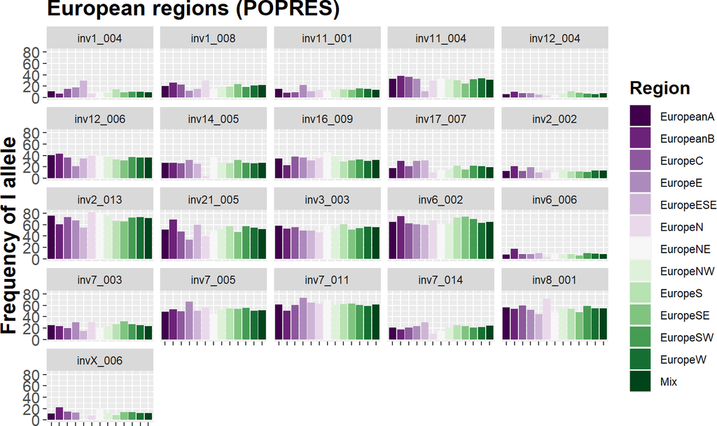

```r
x <- tidyr::gather(freq.EURreg,
                   key="inversion",
                   value="freq", -pop)
colourCount <- length(unique(x$pop))
x2 <- x
p2 <- ggplot(x2, aes(x=pop, y=freq, fill=pop)) +
  geom_bar(stat="identity") + facet_wrap(~ inversion) +
  labs(fill = "Region", x="", y="Frequency of I allele") +
  ggtitle("European regions (POPRES)") +
  scale_fill_manual(values = colorRampPalette
                    (brewer.pal(11, "PRGn"))(colourCount))+
  theme(axis.text.x=element_blank(),
        axis.title.y = element_text(size=16),
        axis.text.y = element_text(size=12),
        title = element_text(face="bold", size=14))

p2
```

We can compare the minor allele frequency of each European region to see whether there is a North-South trend

```r
invs.pops <- grep("^inv", colnames(freq.EURreg2), value = TRUE)
ll <- c("North", "Center", "South")
mat <- matrix(NA, nrow=length(invs.pops), ncol=4)
j <- 1
for (i in invs.pops) {
  freqs.i <- freq.EURreg2[ll,i]
  p.i <- prop.trend.test(round((freqs.i/100)*n.europe,0), n.europe, score=c(1,2,3))$p.value
  mat[j,] <- c(freqs.i, p.i)
  j <- j + 1
}
rownames(mat) <- invs.pops
colnames(mat) <- c("North", "Center", "South", "pvalue")
cbind(round(mat[,1:3],1), pval=round(mat[,4],4))
```

```
          North Center South   pval
inv1_004    8.9    9.1  14.4 0.0057
inv1_008   19.4   21.7  19.1 0.8781
inv11_001  14.3   13.9  14.6 0.8479
inv11_004  32.4   31.3  30.5 0.5287
inv12_004   6.2    7.9  10.9 0.0085
inv12_006  37.4   36.5  33.3 0.1647
inv14_005  26.5   26.9  26.4 0.9823
inv16_009  39.3   32.0  29.1 0.0007
inv17_007  15.1   19.4  22.1 0.0035
inv2_002   13.8   13.5  11.7 0.3199
inv2_013   76.6   71.9  66.4 0.0003
inv21_005  51.6   52.1  57.4 0.0651
inv3_003   53.4   55.2  61.1 0.0140
inv6_002   61.3   65.0  72.8 0.0001
inv6_006    7.3    8.7   8.1 0.6070
inv7_003   22.6   23.3  26.5 0.1605
inv7_005   52.1   51.2  54.4 0.4715
inv7_011   61.0   61.8  62.4 0.6196
inv7_014   20.1   24.0  24.7 0.0775
inv8_001   56.5   54.9  53.6 0.3424
invX_006   12.4   12.1   8.5 0.0400
```

This can be visually inspected in this figure:

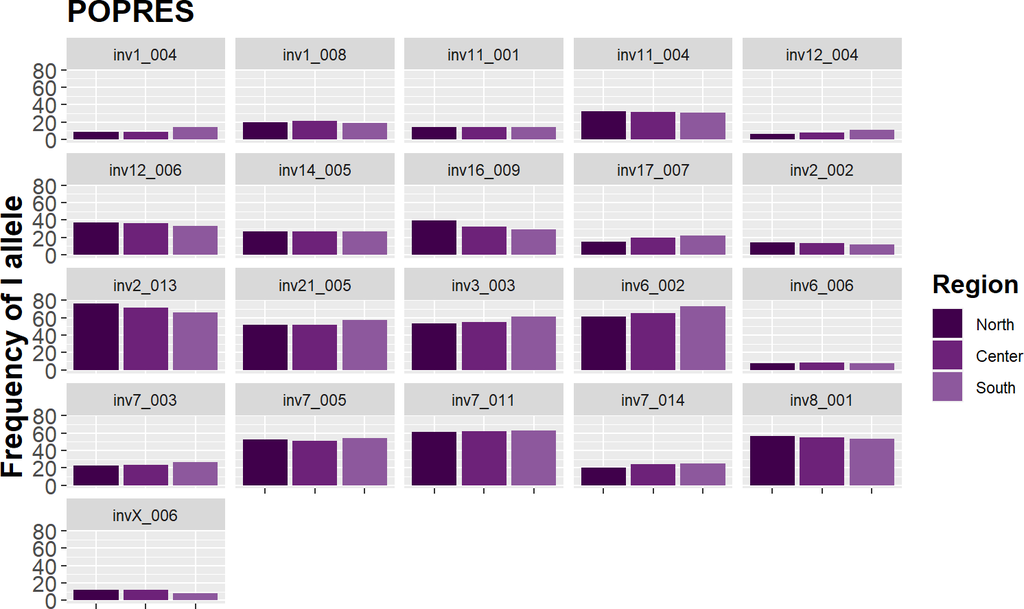

```r
x <- tidyr::gather(freq.EURreg2,
                   key="inversion",
                   value="freq", -pop)
x$pop2 <- factor(x$pop, levels=c("North", "Center", "South"))

p3 <- ggplot(x, aes(x=pop2, y=freq, fill=pop2)) +
  geom_bar(stat="identity") + facet_wrap(~ inversion) +
  labs(fill = "Region", x="", y="Frequency of I allele") +
  ggtitle("POPRES") +
  scale_fill_manual(values = colorRampPalette
                    (brewer.pal(11, "PRGn"))(colourCount))+
  theme(axis.text.x=element_blank(),
        axis.title.y = element_text(size=16),
        axis.text.y = element_text(size=12),
        title = element_text(face="bold", size=14))

p3
```

# 3 Inversion association studies

## 3.1 Discovery analysis: UK Biobank

The object having the results (p-values and sign effect) corresponding to the association analyse is loaded by:

```r
load("UKBiobank/pUKB.Rdata")
```

NOTE: genotypes and fenotypes to get the p-values are avialable in the [UK Biobank repository](https://biobank.ndph.ox.ac.uk/showcase/docs.cgi?id=1)

Then the Figure 2 in the manuscript is created by

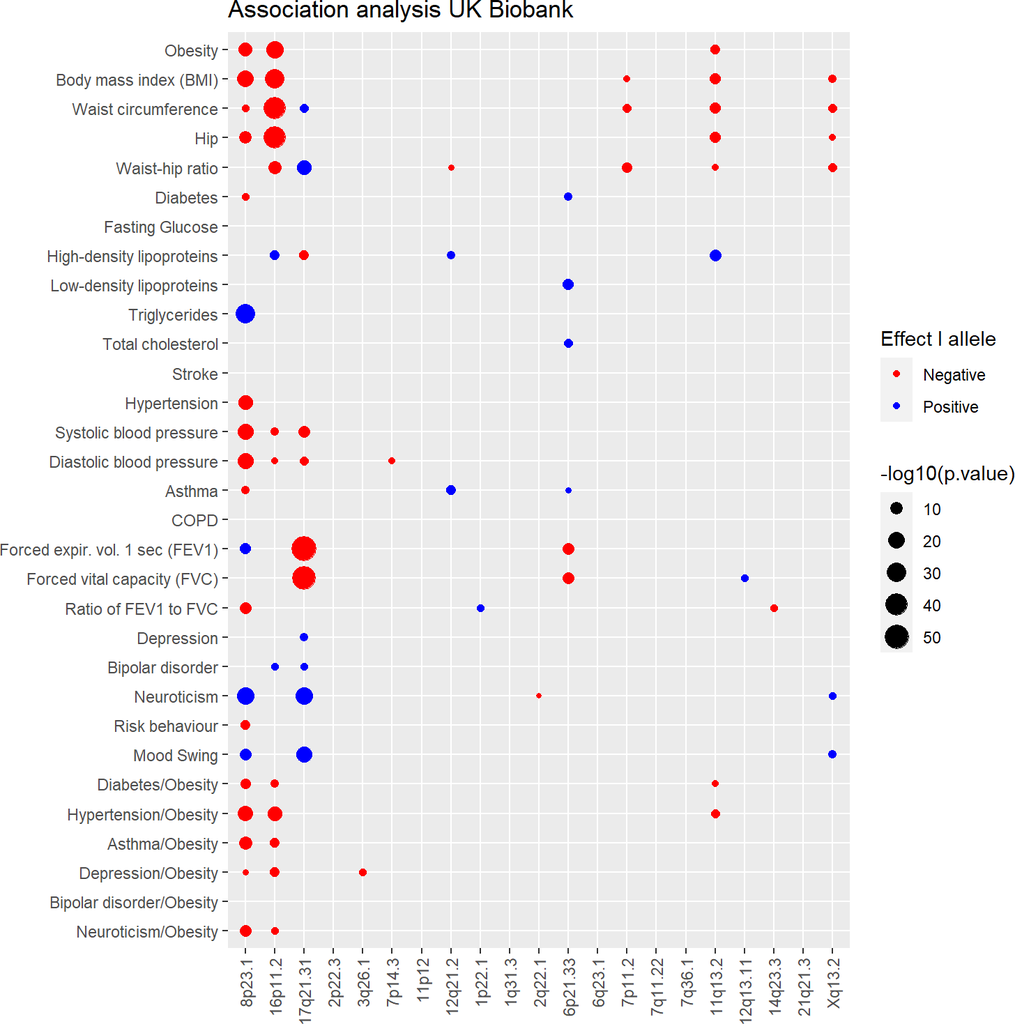

```r
o <- pUKBend$p.value < 0.05/length(invs) &
  !is.na(pUKBend$p.value)

pUKBend$p.value[!o] <- NA
pUKBend$sign[!o] <- NA

pltUKB <- ggplot(pUKBend, aes(x = band, y = label,
                        size=-log10(p.value))) +
    geom_point(aes(col = sign)) +
    scale_color_manual(values=c("red", "blue"),
                       na.translate=FALSE) +
    xlab("") + ylab("") +
    labs(color="Effect I allele") +
    theme(axis.text.x = element_text(angle = 90, vjust=0.5,
                                     hjust=1)) +
    ggtitle("Association analysis UK Biobank")
pltUKB
```

The Odds Ratios are here:

```r
load("UKBiobank/resUKB_final.Rdata")
invs.sel <- c("inv8_001", "inv16_009")
phenos <- c("obesity", "diabetes", "hypertension", "asthma", "depression",
                     "diabetes/obesity", "hypertension/obesity", "asthma/obesity",
                     "depression/obesity")

invOR <- list()
for (i in 1:2){
  a1 <- SNPassoc::odds(ans.ukb$obesity, model="log-add")[invs.sel[i],]
  a2 <- SNPassoc::odds(ans.ukb$diabetes, model="log-add")[invs.sel[i],]
  a3 <- SNPassoc::odds(ans.ukb$hypertension, model="log-add")[invs.sel[i],]
  a4 <- SNPassoc::odds(ans.ukb$asthma, model="log-add")[invs.sel[i],]
  a5 <- SNPassoc::odds(ans.ukb$everDep, model="log-add")[invs.sel[i],]
  a6 <- SNPassoc::odds(ans.ukb$diab.ob, model="log-add")[invs.sel[i],]
  a7 <- SNPassoc::odds(ans.ukb$hyp.ob, model="log-add")[invs.sel[i],]
  a8 <- SNPassoc::odds(ans.ukb$asthma.ob, model="log-add")[invs.sel[i],]
  a9 <- SNPassoc::odds(ans.ukb$ob.dep, model="log-add")[invs.sel[i],]
  invOR[[i]] <- rbind(a1, a2, a3, a4, a5, a6, a7, a8, a9)
  names(invOR[[i]])[4] <- "p.value"
  rownames(invOR[[i]]) <- phenos
}
names(invOR) <- invs.sel
invOR
```

```
$inv8_001
                       OR lower upper      p.value
obesity              1.04  1.03  1.05 2.454896e-13
diabetes             1.04  1.01  1.06 1.103776e-03
hypertension         1.04  1.03  1.05 7.043021e-16
asthma               1.03  1.01  1.04 7.023293e-05
depression           0.98  0.97  1.00 1.194866e-02
diabetes/obesity     1.08  1.05  1.11 3.075840e-07
hypertension/obesity 1.07  1.05  1.08 1.762141e-16
asthma/obesity       1.08  1.06  1.10 2.971730e-11
depression/obesity   1.04  1.02  1.07 1.492646e-03

$inv16_009
                       OR lower upper      p.value
obesity              0.95  0.94  0.96 3.894536e-24
diabetes             0.98  0.96  1.01 1.449974e-01
hypertension         0.99  0.98  1.00 1.198758e-02
asthma               1.00  0.99  1.01 9.529259e-01
depression           1.02  1.00  1.04 1.842159e-02
diabetes/obesity     0.94  0.92  0.97 7.505820e-05
hypertension/obesity 0.94  0.93  0.96 2.698655e-14
asthma/obesity       0.95  0.93  0.97 7.357074e-06
depression/obesity   0.94  0.92  0.97 5.465978e-06
```

# 4 Transcriptomic effects in GTeX